# HW 6: z-tests, t-tests, and effect sizes

# Before you begin

This homework exercise involves you answering some questions, writing some code, and creating a nice HTML file with your results. When asked different questions, simply type your coded or written responses after the ANSWER message. When asked to write code to complete sections, type your code in the empty code blocks that follow the ANSWER message. After adding that code, you must make sure that it will execute. So, remember to read the content and run each line of your code as you write it so that you know it executes correctly. If your code does not execute, then `R Markdown` won’t know what you are telling it to do and your HTML file will not be produced. Also, don’t create your HTML file until you finish and know that all your code works correctly.

## 1. Checking your working directory

Always make sure that your working directory points to Psyc109 on your desktop.

```r
getwd()
```

```
## [1] "X:/Progs/_install/R/Exercises/Homework"
```

1.2. Key functions used for this assignment:

- `as.data.frame()` for combining vectors into a data frame
- `lattice::histogram()` for histograms
- `length()` obtain the length of an object or variable
- `nortest::lillie.test()` or `shapiro.test` for testing normality
- `mean()` obtain the mean of an object or variable
- `options()` for changing the scientific notation display (e.g., scipen = 999)
- `qqnorm()` and `qqline()` for examining normality
- `read.csv()` read in a csv file
- `str()` to obtain the structure of a data.frame
- `subset()` for grabbing select variables from a data.frame
- `summary()` for viewing descriptive statistics of a variable
- `t2r()` for calculting the effect size for a t.test; on my dropbox
- `t.test()` for calculating t-tests; built-in stats library
- `z.test()` for calculating z-test; on my dropbox

## 2. Loading libraries

2.1. Run the code below to download some libraries needed for this assignment. By using `include=FALSE, cache=FALSE` in the `R` code header, we will make sure that any error messages do not appear in the HTML file you create.

If you know what libraries you will use for your code, you can load them now. Use `library()` to load the following libraries: `lattice`, `nortest`, `PerformanceAnalytics`, `moments`, `lattice`, `psych`.

*ANSWER:*

```r
library(lattice)
library(nortest)
library(PerformanceAnalytics)
library(moments)
library(lattice)
library(psych)
#library(asbio)
```

Change from scientific notation if you want.

```r
options(scipen = 999) # to turn on, set: options(scipen=0)
```

# Part A

## 1. Overview of the z-test

1.1. The *z*-test is used to compare a sample mean to a population mean to determine if the population from which the sample was drawn is different from another population. The *z*-test is also only used for variables that are distributed normally. The NHST perspective assumes equivalence between the two populations (e.g., H0: mu1 = mu2), so a difference between the two groups should be 0 on average *IF* the populations have equivalent means. If, however, the sample produces a mean that differs from the population mean, you need to determine how likely such a result would occur under H0. If the likelihood is below your level of acceptable risk of making a Type I error, you could claim that the populations likely differ in their means and that the null hypothesis may not be a reasonable model.

1.2. In order to make such a comparison for the *z*-test, you will need to know the

- **(a)** population mean, mu,
- **(b)** the population standard deviation, sigma,
- **(c)** the sample mean, xbar, and
- **(d)** the sample size, *n*.

Because the standard deviation of sampling distributions is called the standard error of the mean, the *z*-test tells you how many standard errors the sample mean deviates from the population mean. As with extreme *z*-scores, large *z*-test values are less likely to occur due to chance if there is no difference between the population and your sample on your dependent variable.

1.4. Read the `cdc.csv` file the you have used before. Assign it to an object named `HEALTH`.

**ANSWER:**

```r
HEALTH <- read.csv("cdc.csv")
head(HEALTH)
```

```
##     genhlth exerany hlthplan smoke100 height weight wtdesire age sex
## 1      good       0        1        0     70    175      175  77   m
## 2      good       0        1        1     64    125      115  33   f
## 3      good       1        1        1     60    105      105  49   f
## 4      good       1        1        0     66    132      124  42   f
## 5 very good       0        1        0     61    150      130  55   f
## 6 very good       1        1        0     64    114      114  55   f
```

```r
#HEALTH <- read.csv("C:/users/gcook/Desktop/Psyc109/cdc.csv")
# add a constant variable to the data frame (for grouping everyone)
HEALTH$All <- 0
```

1.5. If we wanted to test the average height of people in our sample to that of an average height of a population, we need to specify those values. Obtain the descriptive statistics for `Height` (inches) from your sample data from the `cdc.csv` file. You can use `psych::describeBy` and identify the grouping variable.

```r
#hide
with(HEALTH, psych::describeBy(height, All))
```

```
## group: 0
##    vars     n  mean   sd median trimmed  mad min max range skew kurtosis
## X1    1 20000 67.18 4.13     67   67.13 4.45  48  93    45  0.1    -0.38
##      se
## X1 0.03
```

1.6. You would normally examine whether the heights are distributed normally. We won’t do that here, however, doing so is important. Now that you know the sample’s mean height, you will need to compare that to the population mean. Let’s assume that the average adult height of the population is 67 inches tall (5’7“) with a standard deviation of 3 inches. The population data are also normally distributed. Create an object called `Popmean` and assign it a value of 67; create an object called `Popsd` and assign it a value of 3.

**ANSWER:**

```r
#hide
Popmean <- 67
#hide
Popsd <- 3
```

1.7. The `cdc` data set contains data from very many people (20K). Let’s still just assume that’s a sample for this exercise. However, your samples will be much smaller of course. In order to calculate the standard error of the mean for the *z*-test, you will need to know the size of your sample. Use `length()` to obtain the number of people in your height variable and assign that to a variable named `Samplesize`.

**ANSWER:**

```r
#hide
Samplesize <- with(HEALTH, length(height))

#take a look at it
Samplesize
```

```
## [1] 20000
```

Formula: `z test = (Sample mean - population mean) / (sigma / sqrt(n))`

Ex: `z.test(data = health$??, null.mu = ??, sigma = ??)`

**ANSWER:**

```r
#hide
with(HEALTH, z.test(height, null.mu = Popmean, sigma = Popsd))
```

```
##                           method  mean mu   diff      se     z p.value
## 1 One sample z-test (two-tailed) 67.18 67 0.1829 0.02121 8.622       0
##       n
## 1 20000
```

1.9. **QUESTION** Notice the *z*-test value and the *p*-value for the test. Compare your *p*-value to your alpha .05 and decided whether you would retain or reject H0. State your answer in words.

**ANSWER:**

I would reject H0 because the *p*-value is less than an alpha of .05. The difference between the means observed from the data is unlikely due to random error for a sample of 20K.

1.10. One thing you will have noticed about this test is that when you have very, very, large sample sizes, the standard error of the mean (sigma/sqrt(n)) will be very, very small. Consequently, you may reject H0 even when the sample mean is very close to the population mean. I used this example to illustrate that point and make you become vigilant about data using very large samples.

# Part B

## 1. Overview of the one-sample *t*-test

1.1. The procedures for testing hypotheses described up to this point compared a group of scores to a known population (e.g., z-test). For many research questions, however, you do not have any direct information about the populations you wish to study. In such cases, you can estimate population parameters using sample statistics. These kinds of research situations are very common in behavioral and social science research, where usually the only information available is from the samples. You want to compare the mean of the scores in a sample to a population for which the mean is known but the variance is unknown. Hypothesis testing in this situation is called a *one-sample t-test*.

The *one-sample t-test*, like the *z-test*, compares the mean of a single sample to a hypothesized population value (e.g., mu). Unlike the other *t*-tests (e.g. independent and dependent), this test analyzes data from only one dependent variable.

For example: To test this we are going to create a data set of 20 first year resident female doctors resting systolic blood pressure drawn at random from one area

If you don’t already have data in a data frame, you can combine values into vector variables and then combine them into a data frame object using the built-in `data.frame()` . We will create two vectors by combining values using `c()` to combine them.

```r
Id <- c(1, 2, 3, 4, 5, 6, 7, 8, 9, 10, 11, 12, 13, 14, 15, 16, 17, 18, 19, 20)
Bp <- c(128, 127, 124, 126, 144, 142, 133, 140, 132, 131, 130, 132, 149, 122, 139, 119,136, 129, 126, 128)

BLOOD <- data.frame(Id, Bp) # pass the two vectors into the function to create a date frame object.

# look at the data frame; look for NAs
str(BLOOD)
```

```
## 'data.frame':    20 obs. of  2 variables:
##  $ Id: num  1 2 3 4 5 6 7 8 9 10 ...
##  $ Bp: num  128 127 124 126 144 142 133 140 132 131 ...
```

```r
BLOOD
```

```
##    Id  Bp
## 1   1 128
## 2   2 127
## 3   3 124
## 4   4 126
## 5   5 144
## 6   6 142
## 7   7 133
## 8   8 140
## 9   9 132
## 10 10 131
## 11 11 130
## 12 12 132
## 13 13 149
## 14 14 122
## 15 15 139
## 16 16 119
## 17 17 136
## 18 18 129
## 19 19 126
## 20 20 128
```

1.2. Examining the descriptive statsitics for the mean, standard deviation, and skew.

```r
with(BLOOD, psych::describe(Bp))
```

```
##    vars  n  mean   sd median trimmed  mad min max range skew kurtosis   se
## X1    1 20 131.8 7.74  130.5   131.4 6.67 119 149    30  0.5    -0.63 1.73
```

1.3. Examining Data and Assumptions of *t*-tests.

After determining that your data are either interval or ratio in scale, you should examine whether normality of our data is a reasonable assumption. In the process, you can look for outliers in the data, which you should normally remove, but you don’t have to here.

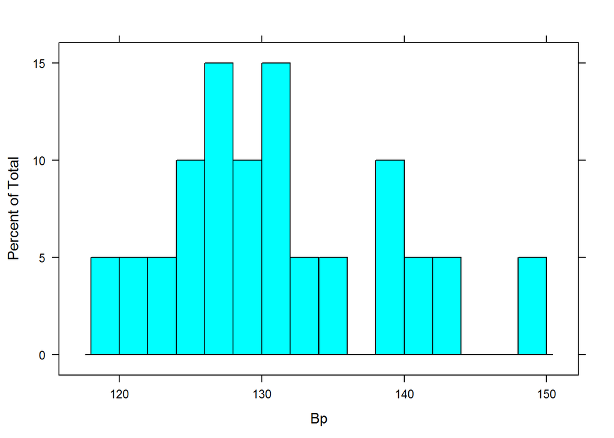

```r
with(BLOOD, lattice::histogram(~Bp, breaks = 20)) # use the breaks argument to manipulate how many breaks to put in your histogram so that you can see the distribution better than the default option
```

You can also examine normal fit using quantile-quantile plots. These plots show theoretical values that are expected for a normal distribution on the x-axis and the sample data on the y-axis. By adding a line to the plot, you can think of the line a what would be predicted for normal data; if the points fall on the line indicates perfect normality, whereas the less they fall along the line, the less likely the data are distributed normally. Severe problems are revealed when most points fall above (or below) the line, which indicates skew. (See also Field pp. 172 or [Q-Q Plots](http://data.library.virginia.edu/understanding-q-q-plots/) ).

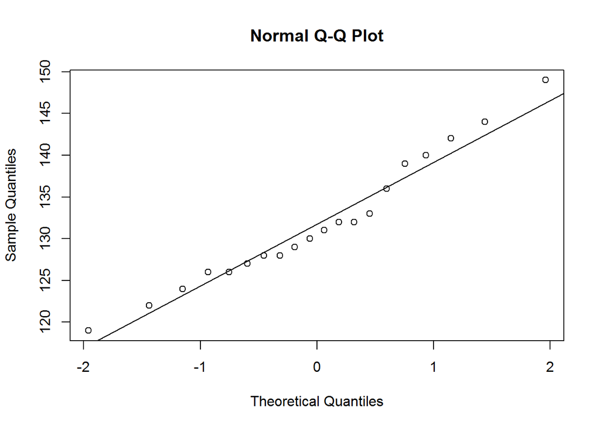

```r
with(BLOOD, qqnorm(Bp))
with(BLOOD, qqline(Bp))
```

1.4. You can also use different statistical tests to examine whether the shape of distribution fits the shape or characteristics of a normal distribution. H0 for these tests is that the distribution is normal in shape, so if the distribution of your data deviates too far from normality, the *p*-value will be small. Some tests are included in the`nortest library`. We will use the Shapiro-Wilk test using `shapiro.test()` and the Lilliefors (Kolmogorov-Smirnov) test for normality using `lillie.test()`.

```r
# pass the variable of interest into the function
with(BLOOD , shapiro.test(Bp)) # The p value is > .05
```

```
##
##  Shapiro-Wilk normality test
##
## data:  Bp
## W = 0.96, p-value = 0.6
```

```r
# pass the variable into the function
with(BLOOD, nortest::lillie.test(Bp)) # The p value is > .05
```

```
##
##  Lilliefors (Kolmogorov-Smirnov) normality test
##
## data:  Bp
## D = 0.14, p-value = 0.4
```

To report the outcome of the Shapiro-Wilk test, the general form is:

*S-W*(df) = test value, *p* < or > alpha

By substitution and making sure to italicize S-W and p, we can say:

The distribution of resting systolic blood pressure for the sample of first year resident female doctors did not differ statistically from that of a normal distribution, *S-W*(19) = .96, *p* > .05. Normality is a reasonable assumption for the sampling distribution.

1.5. If your data adhere to a fairly normal distribution, you can compare your sample mean to a population mean using the one-sample *t*-test. In order to calculate a one-sample *t*-test you must obtain the mean and standard deviation of the sample. You could do this manually as you have before, but functions will also accomplish this. Again, `psych::describe` will be helpful.

```r
with(BLOOD, psych::describe(Bp))
```

```
##    vars  n  mean   sd median trimmed  mad min max range skew kurtosis   se
## X1    1 20 131.8 7.74  130.5   131.4 6.67 119 149    30  0.5    -0.63 1.73
```

Knowing your sample mean and standard deviation you also must know the mean of the population you are testing. From previous large studies of women drawn at random from the healthy general public, a resting systolic blood pressure of 120 mm Hg was predicted as the population mean for the relevant age group.

A data summary:

- Sample mean = 131.85
- Population mean = 120
- Sample size n = 20
- Sample sd = 7.741039

Below is the formula to conduct a one-sample *t*-test:

- `t = (Sample mean - population mean) / (unbiased sample sd / sqrt(n))`

By substitution,

- `t = (131.85 - 120)/ (7.741039)/ sqrt(20))`

1.6. Use `t.test` to calculate the *t*-value and obtain the corresponding *p*-value. Of course, you will need to specify variable and the population mean arguments in `t.test()`.

The general formula is:

- `t.test(dependent variable, mu = population mean)`

```r
# to see the print out only
with(BLOOD, t.test(Bp, mu = 120))
```

```
##
##  One Sample t-test
##
## data:  Bp
## t = 6.8, df = 19, p-value = 0.000002
## alternative hypothesis: true mean is not equal to 120
## 95 percent confidence interval:
##  128.2 135.5
## sample estimates:
## mean of x
##     131.8
```

```r
# or assign the information from the test to an object named something useful like Blood.t
Blood.t <- with(BLOOD, t.test(Bp, mu = 120))
```